# Businees Understanding

## Sentiment on **Data Science/AI** Jobs

Using stackoverflow.com's 2018 survey data to have a better understanding about the general sentiment around the field of Data Science/AI by answering the following 6 questions.

1. Who(country) pays top dollar?
2. Are you satisfied with your job?
3. How does one feel about the future of AI?
4. What area in AI is more interesting?
5. But what about the threat AI poses?
6. Who should take responsibility in preventing the AI apocalypse?

Answering this questions will help an aspiring Data Scientist?/AI engineer to make an informed decision on what direction should set sail.

```python
import pandas as pd
import numpy as np
import matplotlib.pyplot as plt
import seaborn as sns
```

# Data Understanding

### Loading Data

We will load the survey data for year 2018 and filter out for Data roles.

This include the following

- Data Analyst
- Data Engineer
- Data Scientist
- Machine Learning Engineer
- Business Analyst

```python
data_18 = pd.read_csv('Data/developer_survey_2018/survey_results_public.csv',low_memory=False)
data_jobs_mask = (data_18.DevType.str.lower().str.contains('data').fillna(False)) | (data_18.DevType.str.lower().str.contains('learn').fillna(False))
ds_data = data_18[data_jobs_mask]
```

```python
ds_data.head()
```

|  | Respondent | Hobby | OpenSource | Country | Student | Employment | FormalEducation | UndergradMajor | CompanySize | DevType | ... | Exercise | Gender | SexualOrientation | EducationParents | RaceEthnicity | Age | Dependents | MilitaryUS | SurveyTooLong | SurveyEasy |
| --- | --- | --- | --- | --- | --- | --- | --- | --- | --- | --- | --- | --- | --- | --- | --- | --- | --- | --- | --- | --- | --- |
| 1 | 3 | Yes | Yes | United Kingdom | No | Employed full-time | Bachelor’s degree (BA, BS, B.Eng., etc.) | A natural science (ex. biology, chemistry, phy... | 10,000 or more employees | Database administrator;DevOps specialist;Full-... | ... | Daily or almost every day | Male | Straight or heterosexual | Bachelor’s degree (BA, BS, B.Eng., etc.) | White or of European descent | 35 - 44 years old | Yes | NaN | The survey was an appropriate length | Somewhat easy |
| 4 | 7 | Yes | No | South Africa | Yes, part-time | Employed full-time | Some college/university study without earning ... | Computer science, computer engineering, or sof... | 10,000 or more employees | Data or business analyst;Desktop or enterprise... | ... | 3 - 4 times per week | Male | Straight or heterosexual | Some college/university study without earning ... | White or of European descent | 18 - 24 years old | Yes | NaN | The survey was an appropriate length | Somewhat easy |
| 5 | 8 | Yes | No | United Kingdom | No | Employed full-time | Bachelor’s degree (BA, BS, B.Eng., etc.) | Computer science, computer engineering, or sof... | 10 to 19 employees | Back-end developer;Database administrator;Fron... | ... | 1 - 2 times per week | Male | Straight or heterosexual | Secondary school (e.g. American high school, G... | White or of European descent | 18 - 24 years old | No | NaN | The survey was an appropriate length | Somewhat easy |
| 8 | 11 | Yes | Yes | United States | No | Employed full-time | Some college/university study without earning ... | Fine arts or performing arts (ex. graphic desi... | 100 to 499 employees | Back-end developer;C-suite executive (CEO, CTO... | ... | I don't typically exercise | Male | Straight or heterosexual | Some college/university study without earning ... | White or of European descent | 35 - 44 years old | Yes | No | The survey was an appropriate length | Very easy |
| 10 | 17 | Yes | No | Spain | No | Employed full-time | Master’s degree (MA, MS, M.Eng., MBA, etc.) | Information systems, information technology, o... | 1,000 to 4,999 employees | Back-end developer;Database administrator;Mobi... | ... | NaN | NaN | NaN | NaN | NaN | NaN | NaN | NaN | NaN | NaN |

5 rows × 129 columns

#### Columns that are considered for our analysis:

DevType,Country,ConvertedSalary,JobSatisfaction,YearsCodingProf,AIFuture,AIInteresting,AIDangerous,AIResponsible

```python
#Total records available
ds_data[['DevType','Country','ConvertedSalary','JobSatisfaction','YearsCodingProf','AIFuture','AIInteresting','AIDangerous','AIResponsible']].shape
```

```
(21889, 9)
```

```python
#To understand the completeness of data (no.of availble values)
ds_data[['DevType','Country','ConvertedSalary','JobSatisfaction','YearsCodingProf','AIFuture','AIInteresting','AIDangerous','AIResponsible']].count()
```

```
DevType            21889
Country            21889
ConvertedSalary    11839
JobSatisfaction    17365
YearsCodingProf    19723
AIFuture           16795
AIInteresting      15634
AIDangerous        14899
AIResponsible      15658
dtype: int64
```

```python
#No.of null values in the data
ds_data[['DevType','Country','ConvertedSalary','JobSatisfaction','YearsCodingProf','AIFuture','AIInteresting','AIDangerous','AIResponsible']].isna().sum()
```

```
DevType                0
Country                0
ConvertedSalary    10050
JobSatisfaction     4524
YearsCodingProf     2166
AIFuture            5094
AIInteresting       6255
AIDangerous         6990
AIResponsible       6231
dtype: int64
```

```
Standard Deviation: 211271.4538061447
Average Converted Salary: 98780.54683672608
```

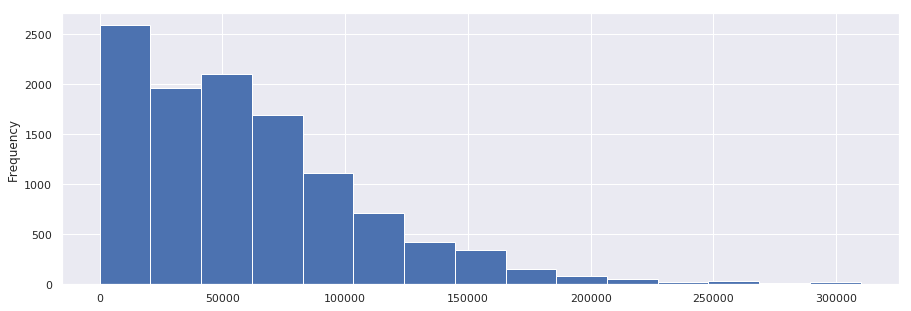

```python
mean = ds_data.ConvertedSalary.mean()
std = ds_data.ConvertedSalary.std()
ds_data.ConvertedSalary[(ds_data.ConvertedSalary<(mean+std))].plot.hist(bins=15);

print('Standard Deviation:',std)
print('Average Converted Salary:',mean)
```

There are lot of null values in the data, they will be handled when there are used to answer a business question. As appropriate and explanation will be provided for the same.

Converted Salary, have a right skewed data.

### Following schema gives us more information on individual columns of 2018 survey data

```python
schema_18 = pd.read_csv('Data/developer_survey_2018/survey_results_schema.csv')
```

```python
schema_18.head()
```

|  | Column | QuestionText |
| --- | --- | --- |
| 0 | Respondent | Randomized respondent ID number (not in order ... |
| 1 | Hobby | Do you code as a hobby? |
| 2 | OpenSource | Do you contribute to open source projects? |
| 3 | Country | In which country do you currently reside? |
| 4 | Student | Are you currently enrolled in a formal, degree... |

### Helper Functions to Understand Data on the fly

Gives the description of the column and prints unique sample values, to get a sense of data present.

```python
# Get easily description and sample data each individual column contains
def get_column_description(col_name):
    '''
    Gives the description of the column

    INPUT:
    col_name - name of the column from survey data

    Prints the description of the column and sample values

    OUTPUT:
    None
    '''
    print('Description : ' + schema_18[schema_18['Column']==col_name]['QuestionText'].values[0])
    print('\nSample values :')
    print(ds_data[col_name].unique()[:15])
```

```python
get_column_description('DevType')
```

```
Description : Which of the following describe you? Please select all that apply.

Sample values :
['Database administrator;DevOps specialist;Full-stack developer;System administrator'
 'Data or business analyst;Desktop or enterprise applications developer;Game or graphics developer;QA or test developer;Student'
 'Back-end developer;Database administrator;Front-end developer;Full-stack developer'
 'Back-end developer;C-suite executive (CEO, CTO, etc.);Data or business analyst;Database administrator;DevOps specialist;Engineering manager;Full-stack developer;System administrator'
 'Back-end developer;Database administrator;Mobile developer;System administrator'
 'Data or business analyst;Data scientist or machine learning specialist;Database administrator;DevOps specialist'
 'Database administrator;Full-stack developer;Mobile developer'
 'Back-end developer;Database administrator;Designer;Desktop or enterprise applications developer;Front-end developer;Full-stack developer'
 'Back-end developer;Database administrator;DevOps specialist;Front-end developer;Full-stack developer;QA or test developer;System administrator'
 'Back-end developer;Data scientist or machine learning specialist;Desktop or enterprise applications developer;Front-end developer;Full-stack developer'
 'Back-end developer;Database administrator;DevOps specialist;Front-end developer;Full-stack developer;Mobile developer'
 'Back-end developer;Database administrator;Front-end developer;Full-stack developer;Mobile developer'
 'Back-end developer;Data or business analyst;Designer;Front-end developer;Game or graphics developer;Mobile developer;Student'
 'Data scientist or machine learning specialist;Student'
 'Back-end developer;Database administrator;Desktop or enterprise applications developer;DevOps specialist;Full-stack developer;QA or test developer']
```

## Top 10 countries to have participated in the survey + Ireland

First, we will identify top 10 countruies to have participated in the survey by no.of participants.

Ireland is not in top 10 countries, but I will add to the analysis, because Dublin, Ireland is considered as one of the top cities for Data Science jobs. And also because I am curious.

```python
countries = list(ds_data['Country'].value_counts().sort_values(ascending=False).index[:10]) #.plot('bar',color=sns.color_palette()[0]);
countries += ['Ireland']
countries
```

```
['United States',
 'India',
 'Germany',
 'United Kingdom',
 'Canada',
 'Brazil',
 'Russian Federation',
 'France',
 'Australia',
 'Netherlands',
 'Ireland']
```

```python
#Filtering data for the above shortlisted countries
country_data = ds_data[ds_data['Country'].isin(countries)].copy()
country_data.shape
```

```
(13683, 129)
```

## Participants per country

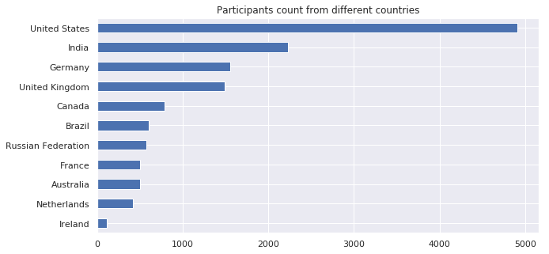

```python
sns.set(rc={'figure.figsize':(10,5)})
country_data['Country'].value_counts(ascending=True).plot('barh',color=sns.color_palette()[0], title = 'Participants count from different countries');
```

# Data Preparation and Analysis

## Five years from now

### How aspirant people in data roles are in general?

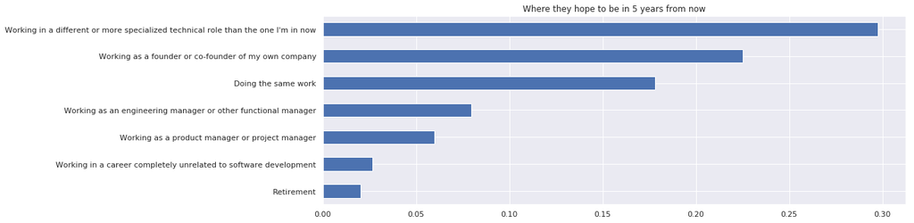

```python
sns.set(rc={'figure.figsize':(15,5)})
(country_data['HopeFiveYears'].value_counts(ascending=True)/len(country_data))\
.plot('barh',color=sns.color_palette()[0],title = 'Where they hope to be in 5 years from now');
```

Majoirty of the participants(30%) belive they will be in a more specilized role than they are now. Which is a little obviuos as the saying goes, "practice makes a programmer perfect".

But it is interesting to see the 2nd highest pole,says that about 22.5% of the participants, i.e., roughly about 1 in every 4, envisions themselves as founders of new company.

## Average salary for a data Scientist per annum in USD

Being dubbed as one of the greatest jobs of 21st century, there is lot of craze around the Data Science jobs. There are many blogs on how to break into the field or what are the best tutorials or what is trending in the technology may it be a progrmamming language or a tool.

Today we will answer some of the less explored questions like, what countries pay top dollar for data scientists, which countries have high satisfaction rate, and what is the general sentiment arond AI.

```python
get_column_description('ConvertedSalary')
```

```
Description : Salary converted to annual USD salaries using the exchange rate on 2018-01-18, assuming 12 working months and 50 working weeks.

Sample values :
[ 70841.  21426.  41671. 250000.     nan]
```

### Who pays top dollar?

#### Handling Missing Values:

To calculate the average all the null values and the zeros are dropped. Because the null values doesnt imply anything and only in rare cases such as unpaid internships the salary will be zero per month and when calculating bottom 20% this will impact the percentile values.

#### Handling Outliers:

Bottom 20% of values are removed to exclude low wages of fresh grads impacting the average salary calculation. Similarly top 20% of values are also excluded assuming they are salaries of industry veterans are rare cases.

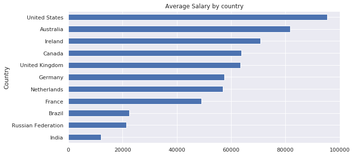

```python
#After dropping null values, 0, and excluding 20th percent values on both sides. Mean is calculated country wise.
sns.set(rc={'figure.figsize':(10,5)})
def mean_(x):
    '''
    Calculates mean for given array, after excluding nulls and outliers (20% on both ends)
    INPUT: numpy array

    OPUTPUT: int

    '''
    x = x.dropna()
    x = x[x!=0]
    x = x[(x.quantile(.2)<x) & (x < x.quantile(.8))]
    return x.mean()

country_data.groupby('Country')['ConvertedSalary'].apply(lambda x:mean_(x)).sort_values(ascending=True).plot('barh',color=sns.color_palette()[0],title = 'Average Salary by country');
```

# Job Satisfaction

"Money is not everything" is quite common saying. So lets us also find out how most people feel about their jobs in respective countries

```python
get_column_description('JobSatisfaction')
```

```
Description : How satisfied are you with your current job? If you work more than one job, please answer regarding the one you spend the most hours on.

Sample values :
['Moderately dissatisfied' 'Slightly satisfied' 'Moderately satisfied'
 'Slightly dissatisfied' 'Extremely satisfied'
 'Neither satisfied nor dissatisfied' nan 'Extremely dissatisfied']
```

```python
get_column_description('CareerSatisfaction')
```

```
Description : Overall, how satisfied are you with your career thus far?

Sample values :
['Neither satisfied nor dissatisfied' 'Moderately satisfied'
 'Slightly satisfied' 'Moderately dissatisfied' 'Extremely satisfied'
 'Slightly dissatisfied' 'Extremely dissatisfied' nan]
```

```python
# Numerical Mapper for Job & Career Satisfaction
from collections import OrderedDict
satisfaction_mapping = OrderedDict({'Extremely dissatisfied':1,'Moderately dissatisfied':2,'Slightly dissatisfied':3,'Neither satisfied nor dissatisfied':4, 'Slightly satisfied':5,'Moderately satisfied':6,'Extremely satisfied':7})
```

```python
schema_18[schema_18.Column.str.lower().str.contains('satis')]
```

|  | Column | QuestionText |
| --- | --- | --- |
| 12 | JobSatisfaction | How satisfied are you with your current job? I... |
| 13 | CareerSatisfaction | Overall, how satisfied are you with your caree... |

```python
job_satis_df = country_data.groupby('Country')['JobSatisfaction'].apply(lambda x:x.value_counts()/len(x.dropna())).reset_index().rename(columns={'level_1':'JobSatisfaction','JobSatisfaction':'percent_p'})
```

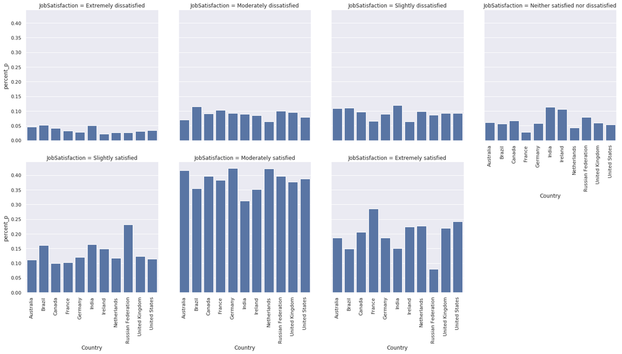

```python
g = sns.catplot(col = 'JobSatisfaction', y = 'percent_p', x = 'Country', data = job_satis_df, col_wrap = 4, kind='bar', color = sns.color_palette()[0] ,col_order = satisfaction_mapping.keys())
g.set_xticklabels(rotation=90);
```

It is very evident from the above graph that irrespective of the country majority of Data Scientists are Moderately satisfied(40%), if not extremly satisfied(20%). That is pretty amazing news for up and coming in the field.

The below graph is to vizsulize the trend, that more are satisfied with the job than not.

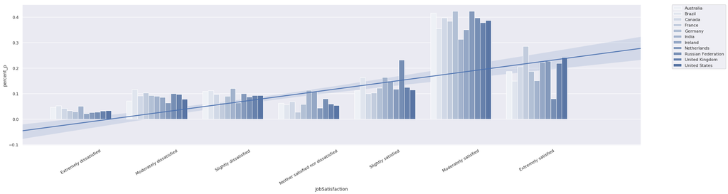

```python
sns.set(rc={'figure.figsize':(30,7)})
# sns.set_style("whitegrid", {'axes.grid' : False})
g = sns.barplot(hue = 'Country', x = 'JobSatisfaction', y = 'percent_p', data = job_satis_df, color = sns.color_palette()[0] ,order = satisfaction_mapping.keys())
sns.regplot(x = job_satis_df['JobSatisfaction'].map(satisfaction_mapping), y = job_satis_df['percent_p'], scatter_kws={'s':0})
g.set_xticklabels(rotation=30,labels = satisfaction_mapping.keys());
plt.legend(bbox_to_anchor=(1.05, 1), loc=2, borderaxespad=0);
```

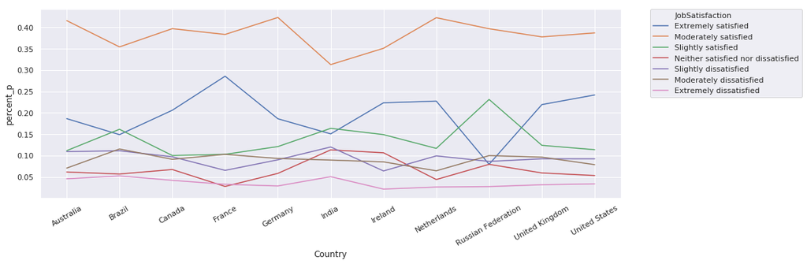

```python
sns.set(rc={'figure.figsize':(15,5)})
g = sns.lineplot(hue = 'JobSatisfaction', x = 'Country', y = 'percent_p', data = job_satis_df, color = sns.color_palette()[0], hue_order = list(satisfaction_mapping.keys())[::-1])
plt.legend(bbox_to_anchor=(1.05, 1), loc=2, borderaxespad=0);
g.set_xticklabels(rotation=30,labels = job_satis_df['Country'].unique());
```

# Sentiment on AI

There are many speculations surrounding the field on AI. Let us understand the data we have at hand to address some of this speculations.

All the null values will be replaced with 'No comments'. This is to understand how many choose not to answer the question.

```python
def get_ai_sentiment_on(col):
    '''
    Multiple Bar Graph for plotting general sentiment on AI for 4 different categories

    INPUT: string - one of the four following columns
    'AIFuture', 'AIResponsible','AIDangerous','AIInteresting'

    OUTPUT: None
    '''
    country_data[col] = country_data[col].fillna('No comments')
    opinion_order = country_data[col].dropna().unique()
    col_name = 'scale_to_100_'+col
    age_order = sorted(list(country_data['YearsCodingProf'].drop_duplicates().dropna().values),key=lambda x:int(x.split('-')[0] if '-' in x else 30));
    data = country_data.groupby('YearsCodingProf')[col].apply(lambda x:x.value_counts()/len(x)*100).reset_index(name=col_name).rename(columns={'level_1':'opinions'})
    g = sns.barplot(hue = 'opinions', x = 'YearsCodingProf', y = col_name, data = data,
                order = age_order, hue_order = opinion_order);#color = sns.color_palette()[0]
    g.set_xticklabels(rotation=30,labels = age_order);
    g.set_title(col)
```

```python
col = 'AIFuture'
get_column_description(col)
print(country_data[col].isna().sum())
country_data[col].value_counts()
```

```
Description : Overall, what's your take on the future of artificial intelligence?

Sample values :
["I'm excited about the possibilities more than worried about the dangers."
 "I'm worried about the dangers more than I'm excited about the possibilities."
 nan "I don't care about it, or I haven't thought about it."]
2947
```

```
I'm excited about the possibilities more than worried about the dangers.        8155
I'm worried about the dangers more than I'm excited about the possibilities.    1870
I don't care about it, or I haven't thought about it.                            711
Name: AIFuture, dtype: int64
```

## How does one feel about the future of AI?

- Are they excited?
- Worried?
- Dont care?

If we look at how people from varied years of Professional experience feel, from the below plot, the response is overwhelming on the positive note. Excitement won by a large margin over other sentiments.

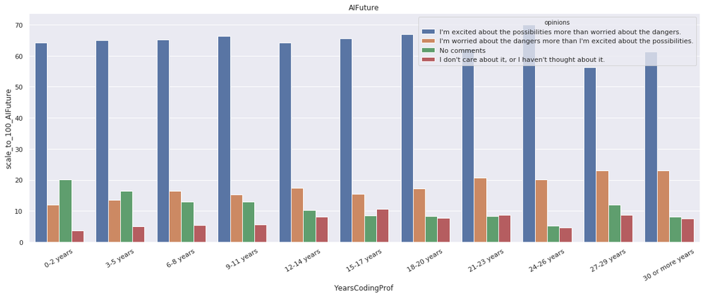

```python
sns.set(rc={'figure.figsize':(20,7)})
get_ai_sentiment_on('AIFuture')
```

```python
col = 'AIInteresting'
get_column_description(col)
print(country_data[col].isna().sum())
country_data[col].value_counts()
```

```
Description : What do you think is the most exciting aspect of increasingly advanced AI technology?

Sample values :
['Increasing automation of jobs' 'Algorithms making important decisions'
 'Artificial intelligence surpassing human intelligence ("the singularity")'
 nan
 'Evolving definitions of "fairness" in algorithmic versus human decisions']
3880
```

```
Increasing automation of jobs                                                3967
Algorithms making important decisions                                        2321
Artificial intelligence surpassing human intelligence ("the singularity")    2294
Evolving definitions of "fairness" in algorithmic versus human decisions     1221
Name: AIInteresting, dtype: int64
```

## Ok, Many are excited about AI. But exactly are they excited about?

Let us ignore those that choose not to answer, they are probably as uncertain as we are. Across the age groups everyone is really happy about "automation of jobs". Which seems reasonable as it will open our schedule to explore other things, maybe.

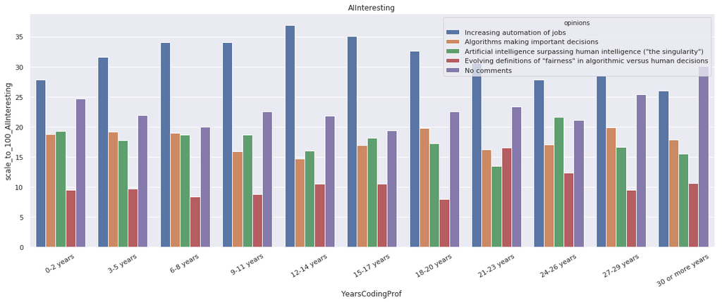

```python
get_ai_sentiment_on('AIInteresting')
```

## But what about the threat AI poses, you ask?

Lets ask the experts.

```python
col = 'AIDangerous'
get_column_description(col)
print(country_data[col].isna().sum())
country_data[col].value_counts()
```

[output not shown]

[figure not shown]

```python
get_ai_sentiment_on('AIDangerous')
```

[output not shown]

```python
col = 'AIResponsible'
get_column_description(col)
print(country_data[col].isna().sum())
country_data[col].value_counts()
```

```
Description : Whose responsibility is it, <u>primarily</u>, to consider the ramifications of increasingly advanced AI technology?

Sample values :
['The developers or the people creating the AI'
 'A governmental or other regulatory body' nan
 'Prominent industry leaders' 'Nobody']
0
```

```
The developers or the people creating the AI    4991
No comments                                     3808
A governmental or other regulatory body         2712
Prominent industry leaders                      1393
Nobody                                           779
Name: AIResponsible, dtype: int64
```

## Whose job is it then? To not let Ultron or Skynet takeover.

Should the creator be responsible for his/her creations? What do you think? Take a moment to think before looking at the poll.

[figure not shown]

```python
get_ai_sentiment_on('AIResponsible')
```

[output not shown]

# Conclusion

All the professional age groups are excited about the future of AI. Most of them are mainly inclined towards having AI automating most of the jobs.

Industry veterans show major concern about letting “AI make important decisions”. While there are about 60% (not enough) don't believe in taking responsibility for their actions in developing AI.